# Statistical Modelling - Series 2

Konstantinos Papadakis (DSML 03400149)

5 January 2022

# Part A

We start by loading the appropriate libraries and the dataset.

```r
library("knitr")
library("car")
library("corrplot")
library("olsrr")
library("glmnet")

vehicles_full <- read.table("./data/vehicles.txt", header = TRUE)

# We can convert the "vs" and "am" to factors, but since they only have two levels,
# with value 0 and 1, we can keep them as is.
# factor_columns <- c("vs", "am")
# df_full[factor_columns] <- lapply(df_full[factor_columns], as.factor)

vehicles <- vehicles_full[-1]
```

We then fit a linear model using all the variables. No variable is significant even though $R^2$ is decent. This leads us to believe that some variables are redundant due to multicollinearity.

```r
mod <- lm(mpg ~ ., vehicles)
summary(mod)
```

```
##
## Call:
## lm(formula = mpg ~ ., data = vehicles)
##
## Residuals:
##     Min      1Q  Median      3Q     Max
## -3.4506 -1.6044 -0.1196  1.2193  4.6271
##
## Coefficients:
##             Estimate Std. Error t value Pr(>|t|)
## (Intercept) 12.30337   18.71788   0.657   0.5181
## cyl         -0.11144    1.04502  -0.107   0.9161
## disp         0.01334    0.01786   0.747   0.4635
## hp          -0.02148    0.02177  -0.987   0.3350
## drat         0.78711    1.63537   0.481   0.6353
## wt          -3.71530    1.89441  -1.961   0.0633 .
## qsec         0.82104    0.73084   1.123   0.2739
## vs           0.31776    2.10451   0.151   0.8814
## am           2.52023    2.05665   1.225   0.2340
## gear         0.65541    1.49326   0.439   0.6652
## carb        -0.19942    0.82875  -0.241   0.8122
## ---
## Signif. codes:  0 '***' 0.001 '**' 0.01 '*' 0.05 '.' 0.1 ' ' 1
##
## Residual standard error: 2.65 on 21 degrees of freedom
## Multiple R-squared:  0.869,  Adjusted R-squared:  0.8066
## F-statistic: 13.93 on 10 and 21 DF,  p-value: 3.793e-07
```

## A.1

We see that there’s large simple collinearity between variables

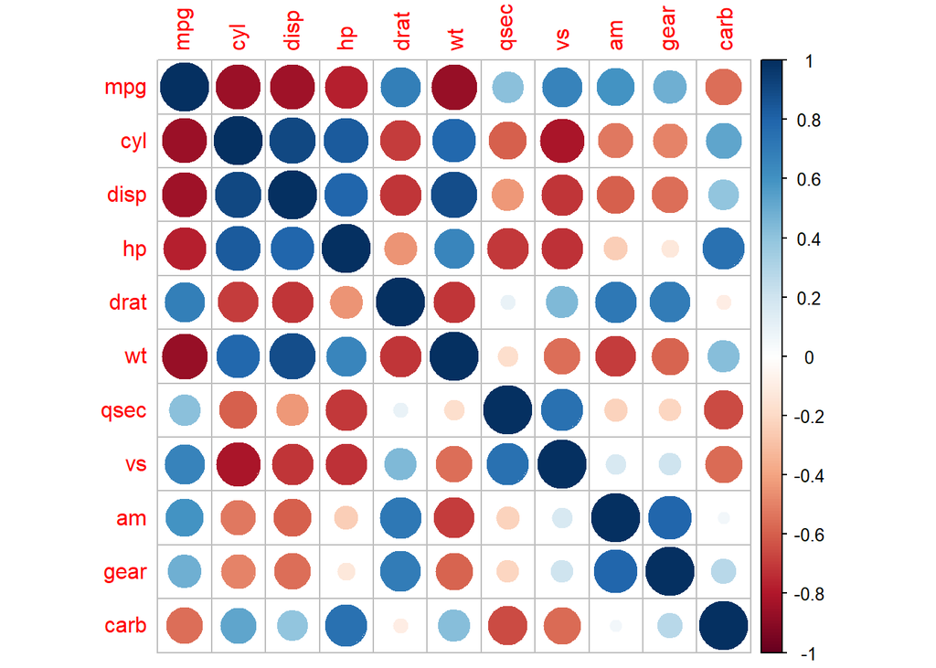

```r
corr_matrix <- cor(vehicles)
corrplot(corr_matrix)
```

The variance inflation factor for almost all variables is above 5, which means that there’s large collinearity among certain subsets of our variables.

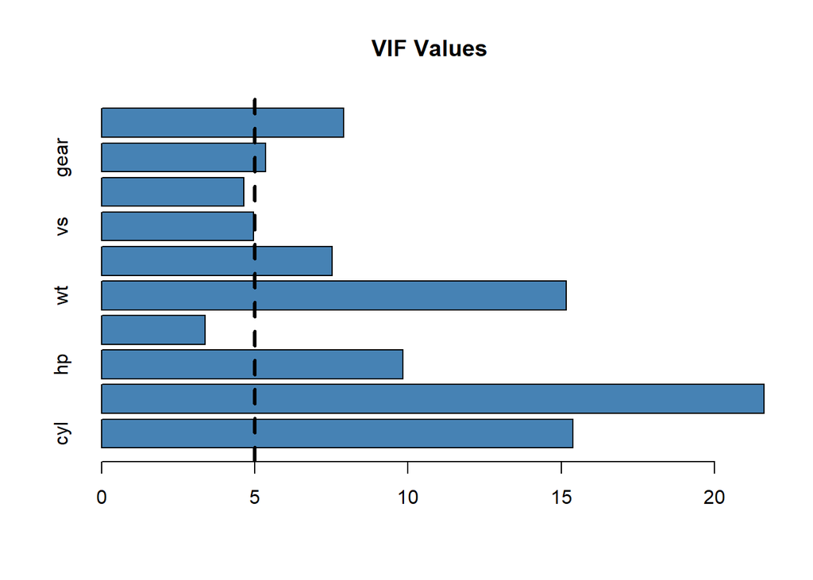

```r
vif_values <- vif(mod)
barplot(vif_values, main = "VIF Values", horiz = TRUE, col = "steelblue")
abline(v = 5, lwd = 3, lty = 2)
```

From the Residuals vs Fitted, we see that the line is not far from horizontal, and that the spread around it is roughly homogenous. Thus, homoscedacity seems to hold. The QQ plot doesn’t look great, so we might need to transform the predicted variable. From the Residuals vs Leverage plot, we see that the two most influential samples are 29 and 9.

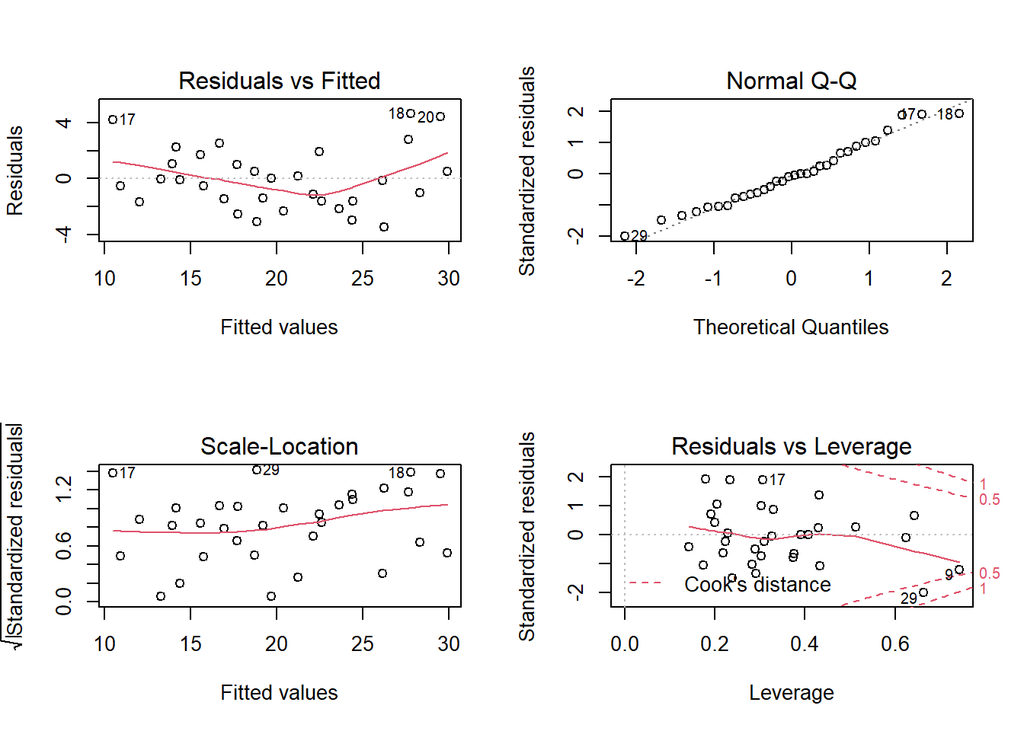

```r
par(mfrow=c(2,2))
plot(mod)
```

```r
par(mfrow=c(1,1))
```

We see that according to the $\frac{2p}{n}$ criterion, samples 9, 29 and 31 can be considered influential.

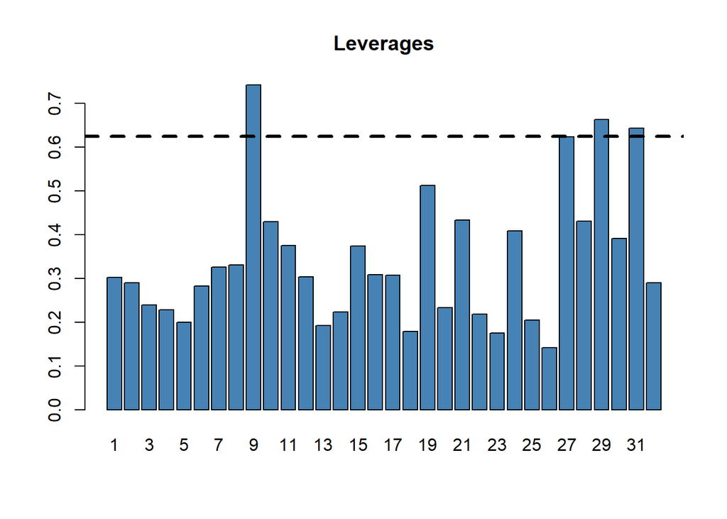

```r
leverages <- hatvalues(mod)
influential_threshold <- 2 * (ncol(vehicles) - 1) / nrow(vehicles)
barplot(leverages, main = "Leverages", col = "steelblue")
abline(h = influential_threshold, lwd = 3, lty = 2)
```

According to Cook’s distance, sample 29 is relatively influential, although its corresponding value is not greater than 1.

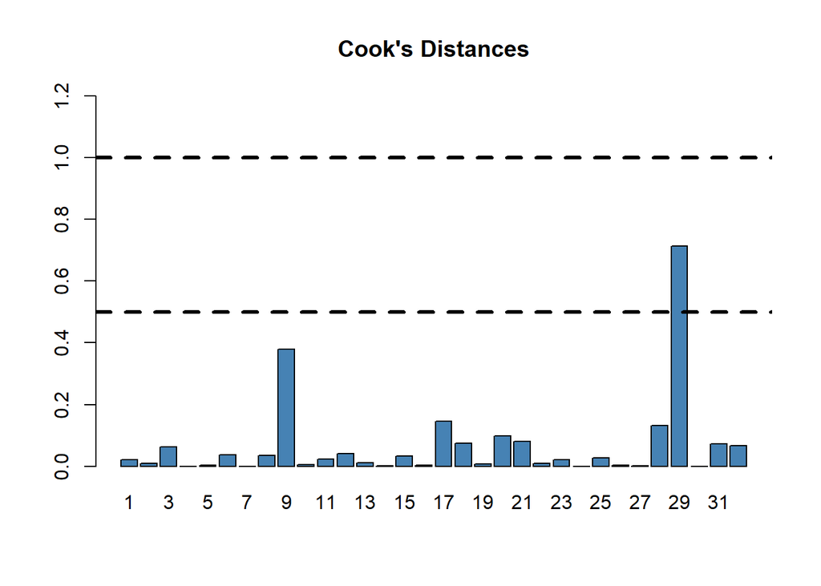

```r
cooks <- cooks.distance(mod)
cooks_thresshold <- c(0.5, 1)
barplot(cooks, main = "Cook's Distances", col = "steelblue", ylim = c(0, max(cooks, 1.2)))
abline(h = cooks_thresshold, lwd = 3, lty = 2)
```

DFFITS also show us that the most influential points are 9 and 29

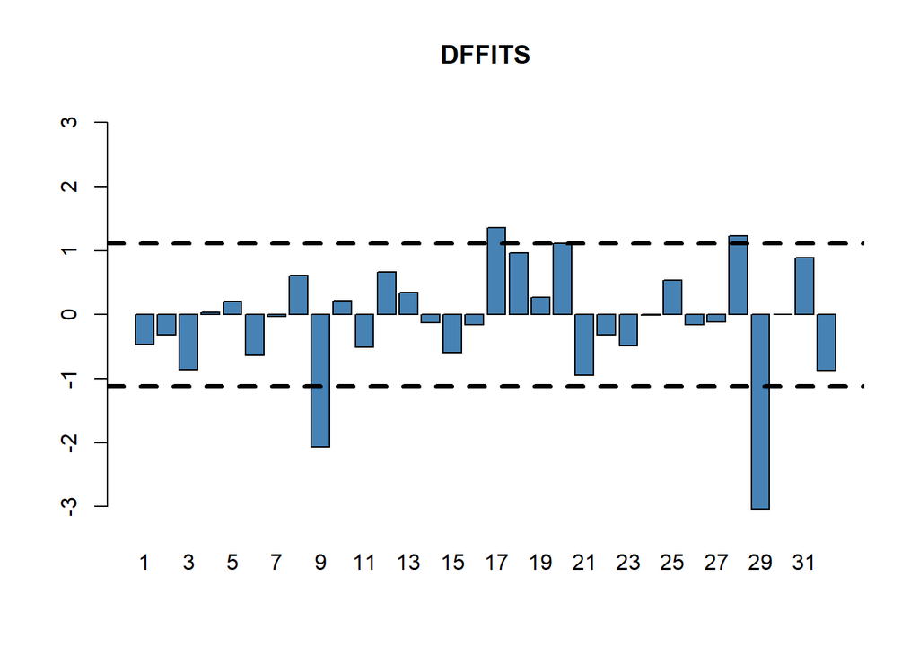

```r
dffits_values <- dffits(mod)
fthresh <- 2 * sqrt((ncol(vehicles) - 1) / nrow(vehicles))
ylim <- max(fthresh, abs(dffits_values)) + 0.2
barplot(dffits_values, main = "DFFITS", col = "steelblue", ylim = c(-ylim, ylim))
abline(h = c(-fthresh, fthresh), lwd = 3, lty = 2)
```

DFBETAS norms also show us that samples 9 and 29 are influential.

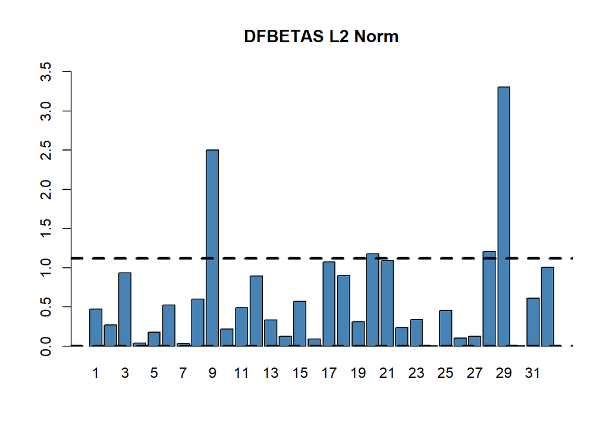

```r
dfbetas_values <- dfbetas(mod)
dfbetas_norms <- apply(dfbetas_values, 1, function(v){sqrt(sum(v^2))})
bthresh <- 2 * sqrt((ncol(vehicles) - 1) / nrow(vehicles))
ylim <- max(bthresh, abs(dfbetas_norms))
barplot(dfbetas_norms, main = "DFBETAS L2 Norm", col = "steelblue",
         ylim = c(0, max(bthresh, dfbetas_norms)+0.2))
abline(h = c(0, bthresh), lwd = 3, lty = 2)
```

We can also view DFBETAS coordinate by coordinate

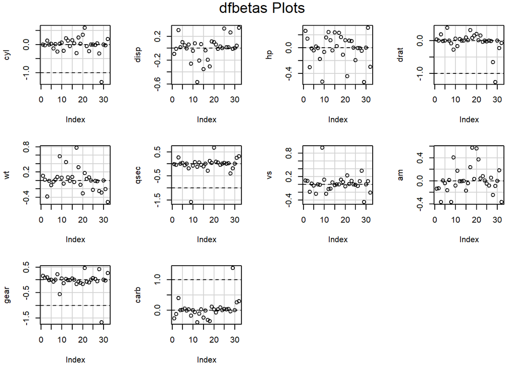

```r
dfbetasPlots(mod, layout=c(3, 4))
```

## A.2

We can use step search …

```r
attach(vehicles)
print("-----FORWARD-----")
mod_forward <- step(
   lm(mpg ~ 1),
   scope = mpg ~ cyl + disp + hp + drat + wt + qsec + vs + am + gear + carb,
   direction = "forward",
   test = "F",
   trace = 100,
)
print("-----BACKWARD-----")
mod_backward <- step(
   lm(mpg ~ ., vehicles),
   scope = NULL,
   direction = "backward",
   test = "F",
   trace = 100,
)
print("-----BOTH-----")
mod_both<- step(
   lm(mpg ~ 1),
   scope = mpg ~ cyl + disp + hp + drat + wt + qsec + vs + am + gear + carb,
   direction = "both",
   test = "F",
   trace = 100,
)
detach(vehicles)
```

… but since our variables are only 10, and our samples only 32, we can simply try out all possible $2^10 - 1 = 1023$ models and pick the best one according to some measure (e.g. AIC).

```r
steps_all <- ols_step_all_possible(mod)
steps_all <- steps_all[order(steps_all$aic), ]
kable(steps_all[1:10, ], caption = "10 Best results according to AIC")
```

10 Best results according to AIC

|  | mindex | n | predictors | rsquare | adjr | predrsq | cp | aic | sbic | sbc | msep | fpe | apc | hsp |
| --- | --- | --- | --- | --- | --- | --- | --- | --- | --- | --- | --- | --- | --- | --- |
| 157 | 56 | 3 | wt qsec am | 0.8496636 | 0.8335561 | 0.7945881 | 0.1026357 | 154.1194 | 65.71383 | 161.4481 | 193.9735 | 6.801667 | 0.1932897 | 0.2239232 |
| 332 | 176 | 4 | hp wt qsec am | 0.8578510 | 0.8367919 | 0.8021094 | 0.7899838 | 154.3274 | 67.22992 | 163.1218 | 190.4637 | 6.854698 | 0.1947968 | 0.2280149 |
| 375 | 177 | 4 | wt qsec am carb | 0.8568000 | 0.8355852 | 0.7974789 | 0.9584920 | 154.5631 | 67.37905 | 163.3575 | 191.8720 | 6.905381 | 0.1962371 | 0.2297008 |
| 528 | 386 | 5 | disp hp wt qsec am | 0.8637377 | 0.8375334 | 0.7984327 | 1.8462076 | 154.9740 | 69.30727 | 165.2341 | 189.8793 | 7.007977 | 0.1991526 | 0.2360582 |
| 65 | 57 | 3 | cyl hp wt | 0.8431500 | 0.8263446 | 0.7956775 | 1.1469220 | 155.4766 | 66.69620 | 162.8053 | 202.3777 | 7.096360 | 0.2016643 | 0.2336250 |
| 297 | 178 | 4 | disp wt qsec am | 0.8525729 | 0.8307319 | 0.7864631 | 1.6361946 | 155.4940 | 67.97009 | 164.2884 | 197.5358 | 7.109218 | 0.2020297 | 0.2364813 |
| 81 | 58 | 3 | cyl wt carb | 0.8424582 | 0.8255787 | 0.7971622 | 1.2578387 | 155.6175 | 66.79836 | 162.9461 | 203.2703 | 7.127660 | 0.2025538 | 0.2346555 |
| 621 | 387 | 5 | drat wt qsec am carb | 0.8607945 | 0.8340242 | 0.7892874 | 2.3180695 | 155.6578 | 69.67512 | 165.9179 | 193.9805 | 7.159344 | 0.2034542 | 0.2411568 |
| 606 | 388 | 5 | hp wt qsec am carb | 0.8607170 | 0.8339318 | 0.7942247 | 2.3305020 | 155.6756 | 69.68474 | 165.9358 | 194.0886 | 7.163332 | 0.2035675 | 0.2412912 |
| 241 | 179 | 4 | cyl wt qsec am | 0.8509966 | 0.8289220 | 0.7792214 | 1.8889178 | 155.8344 | 68.18706 | 164.6288 | 199.6479 | 7.185232 | 0.2041899 | 0.2390098 |

We now fit the model using the variable subset with the smallest AIC value.

```r
step_min_aic <- steps_all[1, ]
best_vars <- strsplit(step_min_aic$predictors, " ")[[1]]
best_formula1 <- as.formula(paste("mpg", "~", paste0(best_vars, collapse = "+")))
best_mod1 <- lm(best_formula1, vehicles)
```

The F-test and the t-test results show that all variables are significant. $R^2$ dropped only by 0.0193522

```r
summary(best_mod1)
```

```
##
## Call:
## lm(formula = best_formula1, data = vehicles)
##
## Residuals:
##     Min      1Q  Median      3Q     Max
## -3.4811 -1.5555 -0.7257  1.4110  4.6610
##
## Coefficients:
##             Estimate Std. Error t value Pr(>|t|)
## (Intercept)   9.6178     6.9596   1.382 0.177915
## wt           -3.9165     0.7112  -5.507 6.95e-06 ***
## qsec          1.2259     0.2887   4.247 0.000216 ***
## am            2.9358     1.4109   2.081 0.046716 *
## ---
## Signif. codes:  0 '***' 0.001 '**' 0.01 '*' 0.05 '.' 0.1 ' ' 1
##
## Residual standard error: 2.459 on 28 degrees of freedom
## Multiple R-squared:  0.8497, Adjusted R-squared:  0.8336
## F-statistic: 52.75 on 3 and 28 DF,  p-value: 1.21e-11
```

# A.3

As we noted before, the qqplot of the regressand doesn’t look great. We’ll try to take the logarithm of it incase it follows a lognormal distribution.

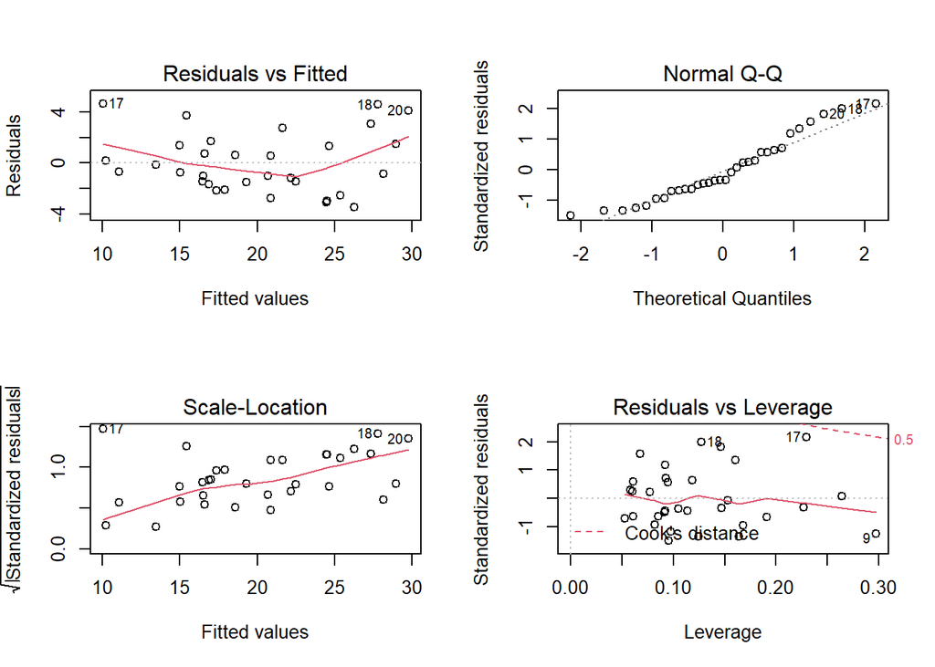

```r
par(mfrow=c(2,2))
plot(best_mod1)
```

```r
par(mfrow=c(1,1))
```

We regress on $\log(\textrm{mpg})$.

```r
best_formula2 <- as.formula(paste("log(mpg)", "~", paste0(best_vars, collapse = "+")))
best_mod2 <- lm(best_formula2, vehicles)
```

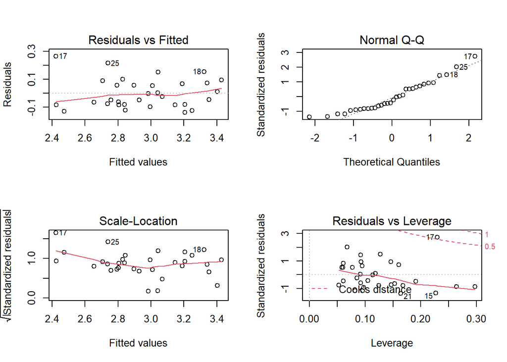

```r
par(mfrow=c(2,2))
plot(best_mod2)
```

```r
par(mfrow=c(1,1))
summary(best_mod2)
```

```
##
## Call:
## lm(formula = best_formula2, data = vehicles)
##
## Residuals:
##      Min       1Q   Median       3Q      Max
## -0.13879 -0.08114 -0.03466  0.07030  0.26575
##
## Coefficients:
##             Estimate Std. Error t value Pr(>|t|)
## (Intercept)  2.69410    0.31326   8.600 2.40e-09 ***
## wt          -0.22456    0.03201  -7.015 1.25e-07 ***
## qsec         0.05329    0.01299   4.101  0.00032 ***
## am           0.08558    0.06351   1.347  0.18863
## ---
## Signif. codes:  0 '***' 0.001 '**' 0.01 '*' 0.05 '.' 0.1 ' ' 1
##
## Residual standard error: 0.1107 on 28 degrees of freedom
## Multiple R-squared:  0.8752, Adjusted R-squared:  0.8619
## F-statistic: 65.47 on 3 and 28 DF,  p-value: 9.036e-13
```

We now attempt $l1$ and $l2$ regularization. We will attempt to use both (i.e. elastic net), with weights $\alpha = 0.2$ for $l1$ and $1 - \alpha = 0.8$ for $l2$. `glmnet` tries multiple values for the regularization parameter $\lambda$.

```r
y <- log(vehicles$mpg)
x <- vehicles[best_vars]
elastic_mod <- glmnet(x, y, alpha = 0.2, family = "gaussian")
```

We notice that the smaller $lambda$ gets, the better the $R^2$ value (`%Dev`) with the maximum reached at 0.8751807, which is the same as the original model. This results indicates that our model is simple enough to the point where it doesn’t need any regularization.

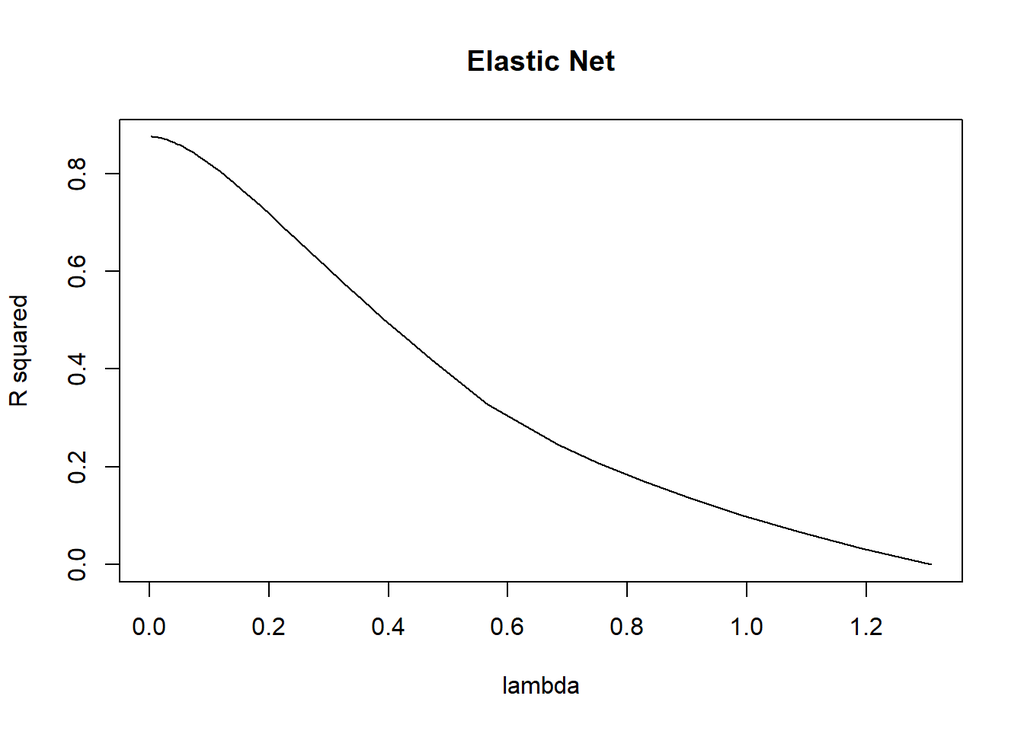

```r
plot(elastic_mod$lambda, elastic_mod$dev.ratio, type = "l", lty = 1,
     main = "Elastic Net", xlab = "lambda", ylab = "R squared")
```

We see that the there’s much less multicollinearity now, as expected.

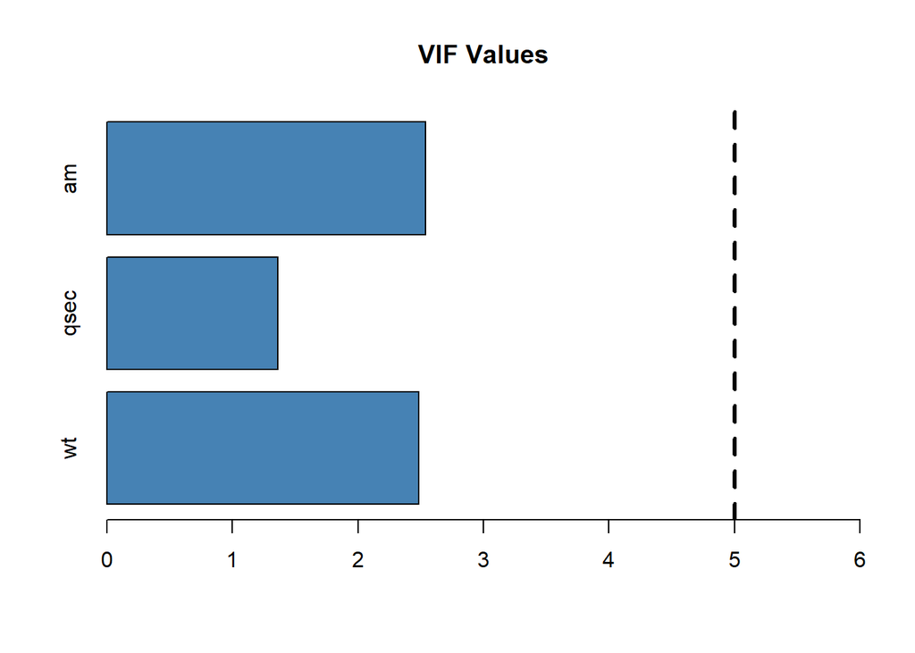

```r
barplot(vif(best_mod2), main = "VIF Values", horiz = TRUE, col = "steelblue", xlim = c(0, 6))
abline(v = 5, lwd = 3, lty = 2)
```

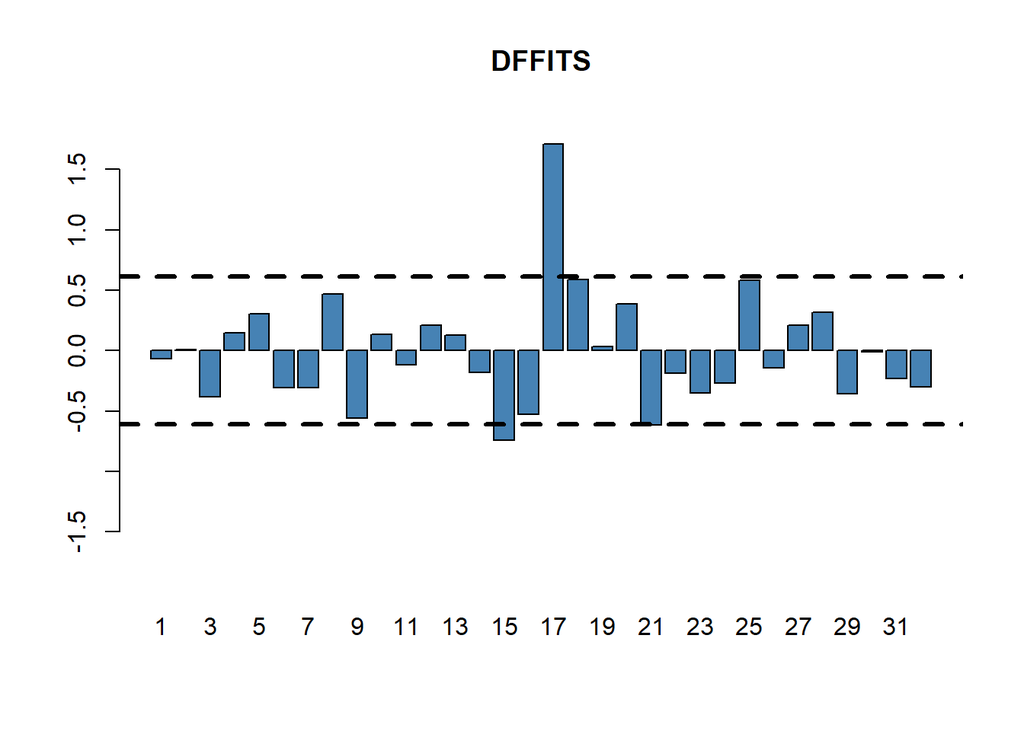

```r
dffits_values <- dffits(best_mod2)
fthresh <- 2 * sqrt((length(best_mod2$coefficients) - 1) / nrow(vehicles))
ylim <- max(fthresh, abs(dffits_values)) + 0.2
barplot(dffits_values, main = "DFFITS", col = "steelblue", ylim = c(-ylim, ylim))
abline(h = c(-fthresh, fthresh), lwd = 3, lty = 2)
```

Added variable plots: We see that there is a linear relationship between the predicted variable and each predictor variable, separately. This means that all variables belong to the model.

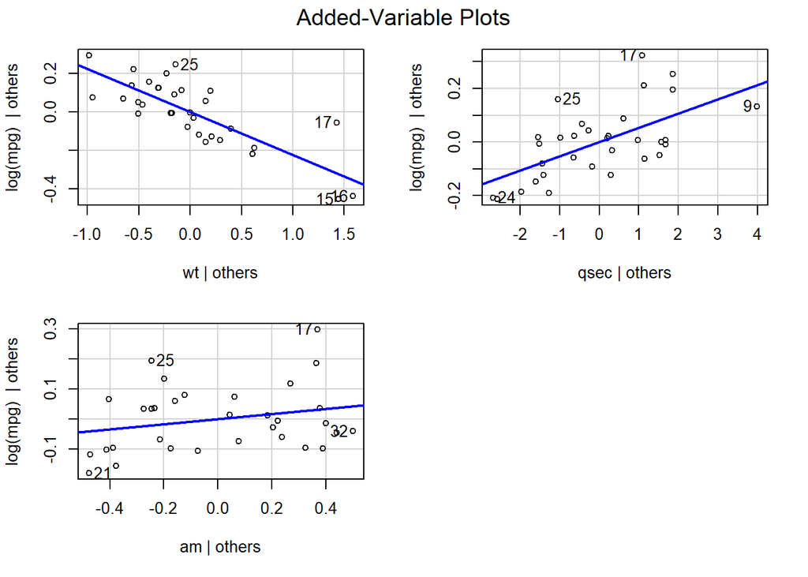

```r
avPlots(best_mod2)
```

Partial residual plots: for each variable we have that the residual and the component curves are relatively close to each other, thus all the variables belong to the model.

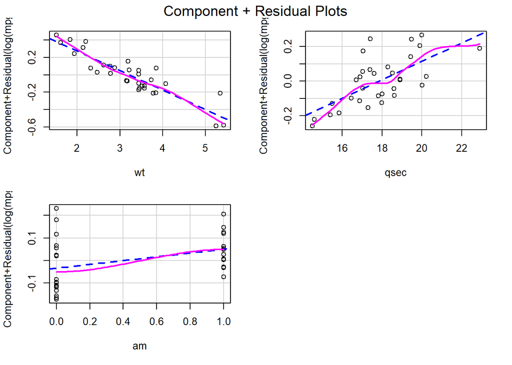

```r
crPlots(best_mod2)
```

Confidence intervals for the model’s coefficients.

```r
cbind(
  best_mod2$coefficients,
  confint(best_mod2, level = 0.95)
)
```

```
##                               2.5 %      97.5 %
## (Intercept)  2.69409612  2.05240274  3.33578950
## wt          -0.22455989 -0.29013462 -0.15898517
## qsec         0.05328768  0.02667156  0.07990379
## am           0.08557580 -0.04451343  0.21566503
```

We create a synthetic data point, similar to 19.

```r
synthetic_x <- list(wt = 1.6, qsec = 18.5, am = 1)
```

Confidence interval of the expected value of the prediction

```r
log_conf <- predict(best_mod2, synthetic_x, interval = "confidence", level = 0.95)
conf <- exp(log_conf)
conf
```

```
##       fit      lwr      upr
## 1 30.1504 27.87311 32.61374
```

Prediction interval of the value of the prediction

```r
log_pred <- predict(best_mod2, synthetic_x, interval = "prediction", level = 0.95)
pred <- exp(log_pred)
pred
```

```
##       fit      lwr      upr
## 1 30.1504 23.71881 38.32598
```

**Interpretation of the coefficients**